# Web Design 101

TUJ Fall 2020

# Interaction with JavaScript

🎉

#### Today’s Agenda

- **Practice / Code-along**
- 3 ways of Adding CSS
- Cascading Review
- Review
- break
- intro to Javascript
- Practice

# Practice / Code-along

1. You: Add the missing HTML
2. Together: deploy to Netlify

[https://stackblitz.com/fork/dribbble-inspo-practice](https://stackblitz.com/edit/dribbble-inspo-practice)

(Here is a link to the ‘solution’ we worked on in class)

https://stackblitz.com/fork/dribbble-inspo-final

# 3 ways of Adding CSS

- Linking an exernal script
- Internal with `<style>` tag
- Inline with style attribute

### External

```html
  <head>
    <title>My Page with CSS</title>
    <link rel="stylesheet" href="styles.css">
  </head>
```

### Internal

```html
<head>
    <title>My Page with CSS</title>
    <style>
      body {
        color: blue;
      }
    </style>
</head>
```

### Inline

```html
<div class="my-div" style="color:red;">I will be red!</div>
```

# Cascading review

If there are multiple or conflicting rules for a single element, only one will be applied.

Cascade is the algorithm (or ruleset) that’s used to determine which is applied

- Order
- Specificity

Order - the order in which your rules are written matters.

Things at the bottom override things at the top

Specificity - the more specific rule will have priority over a more general rule, even if that general rule comes later

inline styles have highest specificity

**index.html**

```
<p style="color: red">This is my paragraph.</p>
```

**styles.css**

```
p {
  color: green;
}
```

```
<div class="green">
  <p class="red">This is my paragraph.</p>
</div>
```

```
.green .red {
  color: green;
}

.red {
  color: red;
}
```

```
.red {
  color: red !important;
}
```

# Review

How do you write a comment in HTML?

```html
<!-- hello world -->
```

How do you write a comment in CSS?

```css
/* max-width: 1100px; */
```

## Who do we design for?

Humans / Users

## In CSS, what is a selector?

The part of the CSS rule that **selects** an element in our html to modify

In CSS, how would we write the selector for the following html element?

```html
  <p class="green">Green text</p>
```

```css
  p { }
```

```css
  .green { }
```

### What does this css property do?

`border`

Shorthand for adding a border to your element

```css
button {
  border: 2px solid black;
}
```

```css
border-color: black;
border-style: solid;
border-width: 2px;
```

What are the 4 parts of the Box Model?

- content
- padding
- border
- margin

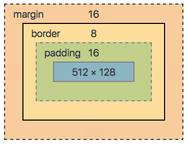

# What is JavaScript

“JavaScript (JS) is a lightweight, interpreted, or just-in-time compiled programming language with first-class functions. While it is most well-known as the scripting language for Web pages, many non-browser environments also use it, such as Node.js, Apache CouchDB and Adobe Acrobat. JavaScript is a prototype-based, multi-paradigm, single-threaded, dynamic language, supporting object-oriented, imperative, and declarative (e.g. functional programming) styles.”

https://developer.mozilla.org/en-US/docs/Web/JavaScript

It’s a programming language.

It’s an interpreted programming language.

It is not the same as Java.

## No :-(

[figure not shown]

## Yes :-)

[figure not shown]

```javascript
const sayHello = function(){
   console.log('Hello');
}

sayHello();
```

## Why should you care?

Because it is the primary scripting language for the web.

- Interaction
- Incorporate 3rd party functionality like social media
- Local Data Storage
- Changing the content of a page dynamically

## The structure of a web page

> Content & Structure

HTML

> Presentation

CSS

> Interaction

JavaScript

## How do we use JavaScript?

## Review

How do you include a stylesheet in your website?

- Inline with style attribute
- Internal with `<style>` tag
- Linking an exernal script

## Take a guess?

How do you include JavaScript in a web site?

- Inline with interactive attributes
- Internal with `<script>` tag
- Link to an exernal script

```html
<button onClick='console.log("I have been clicked!")'>
  Click me
</button>
```

```html
<script>
  alert("I am a JavaScript alert.");
</script>
```

```html
<head>
  <title>My Page with CSS</title>
  <link rel="stylesheet" href="styles.css">
  <script src="myscript.js"></script>
</head>
```

## Tip

Add your external js file at the *end* of your html document

```html
<body>
  <p>All my great content...</p>

  <script src="script.js"></script>
</body>
```

## How do we interact with elements on our page?

Selectors

The DOM

Document Object Model

A representation of your HTML, stored in your browser’s memory when you load a web page.

The DOM lets you connect your js to what the user sees in the browser window.

## Selectors

- HTML tag
- element id
- element class
- data attributes
- combining all of the above

```javascript
getElementById()
getElementsByTagName()
getElementsByClassName()

querySelector()
querySelectorAll()
```

```javascript
querySelectorAll('[data-action="expand"]')
```

## Cool, I can select elements!

Wait… now what?

## Fundamental JavaScript building blocks

- variables
- functions

## variables

Let you store, reuse, and update data.

```javascript
let myNumber = 3;
myNumber = 4;
console.log("This is my number: " + myNumber);
```

```javascript
document.getElementById('really-useful-element');
```

```javascript
document.getElementById('really-useful-element')
  .innerHTML="New content";
```

```javascript
document.getElementById('really-useful-element')
  .style.color = "red";
```

```javascript
const reallyUsefulElement =
document.getElementById('really-useful-element');
```

```javascript
reallyUsefulElement.innerHTML = "New content";
```

```javascript
reallyUsefulElement.style.color = "red";
```

## JS keywords for creating a variable

`var`

`const`

`let`

## functions

Functions let you store and reuse a group of commands

```javascript
function contentChanger(element) {
  element.innerHTML = "New content";
  element.style.color = "red";
}

const reallyUsefulElement =
document.getElementById('really-useful-element');

contentChanger(reallyUsefulElement);
```

## JS keywords for creating a function

```
function myFunction(parameter) = {
  // Your statements here
}
```

```
const myFunction = (parameter) => {
  // Your statements here
}
```

# Practice

[https://stackblitz.com/fork/dribbble-inspo-practice](https://stackblitz.com/edit/dribbble-inspo-practice)